# Progenitor seurat qc and analysis

previous code: mito_on_mad_take2_full now updating seuratv5

```r
module = "progenitors"
dataname = "initial"#<- to load / to save -> dataname = "regress_out"
library(here); i_am(file.path("analysis",paste(module,sep="_",dataname,"seurat_analysis.Rmd")))
indir = here("data/cellranger/count_no_introns/day0")
odir = here("output", module, dataname)


if (!dir.exists(odir)){dir.create(odir, recursive = T)}
load_data = T
subset_data = F #subset data to 10% total cells?
```

```r
library(dplyr, quietly = T)
library(ggplot2)
library(ggsci)

library(Seurat)
library(BPCells)
library(patchwork)
library(clusterProfiler, quietly = T)
library(enrichplot)
```

```r
pal = c("#DA1819", "#00AED1", "#434D51","#EBB400","#691A93","#3AAD00")
library(RColorBrewer)
library(ggsci)
clusters = ggsci::pal_simpsons()(13)[c(1:7,9:13)]
spectral =  rev(brewer.pal(n = 11, name = "Spectral"))

#clusters = c("#FED439FF", "#709AE1FF", "#8A9197FF", "#D2AF81FF",
 #            "#FD7446FF", "#D5E4A2FF", "#197EC0FF", "#46732EFF", "#71D0F5FF")
```

## Read data

This filtered matrix has been filtered for cells with low UMI counts already (EmptyDrops method).  
If first run, save bpcells objects, otherwise load data. Can work on a subset if subset_data=T

```r
samples = list.dirs(here(indir), full.names = F, recursive = F)
samples
```

```
## [1] "day0_subjectS1" "day0_subjectS2" "day0_subjectS3" "day0_subjectS4"
## [5] "day0_subjectS5" "day0_subjectS6"
```

```r
if (load_data==FALSE){# load count matrices

  data_list = c()

  for (s in samples){
    #if this has been run before delete bp dir
    bc_matrix = Read10X(data.dir = here(indir, s, "outs/filtered_feature_bc_matrix"))
    so = CreateSeuratObject(counts=bc_matrix, project=s, names.field = 2, names.delim = "-")
    write_matrix_dir(mat=so[["RNA"]]$counts, dir = here(odir, "bpcells", s))
    gene_mat = open_matrix_dir(here(odir, "bpcells", s))
    so[["RNA"]]$counts = gene_mat

    data_list = c(data_list,so)
  }
  names(data_list) = samples
  aggr = merge(data_list[[1]], y= data_list[2:length(data_list)],
               add.cell.ids = gsub("_",".",samples), project=dataname )

  saveRDS(aggr,here(odir,"unfiltered_object.rds"))


  rm(data_list, bc_matrix, so)
} else if(load_data){
  aggr = readRDS(here(odir, "unfiltered_object.rds"))
}

aggr
```

```
## An object of class Seurat
## 36601 features across 59720 samples within 1 assay
## Active assay: RNA (36601 features, 0 variable features)
##  6 layers present: counts.day0_subjectS1, counts.day0_subjectS2, counts.day0_subjectS3, counts.day0_subjectS4, counts.day0_subjectS5, counts.day0_subjectS6
```

```r
head(aggr@meta.data) #auto metadata
```

```
##                                   orig.ident nCount_RNA nFeature_RNA
## day0.subjectS1_AAACCTGAGACCCACC-1          1       8367         2759
## day0.subjectS1_AAACCTGAGACTAGAT-1          1      55298         7326
## day0.subjectS1_AAACCTGAGCTGTCTA-1          1      15710         3897
## day0.subjectS1_AAACCTGAGTACGACG-1          1      18328         4488
## day0.subjectS1_AAACCTGCAAACTGCT-1          1      23579         4820
## day0.subjectS1_AAACCTGCAAGGCTCC-1          1      15057         3796
```

```r
dataname = "regess_out"
odir = here("output", module, dataname)
if (!dir.exists(odir)){dir.create(odir, recursive = T)}
```

```r
aggr$subject = gsub("_.*","", gsub("day0.subject","",colnames(aggr)))
Idents(aggr) = "subject"
aggr$orig.ident = aggr$subject
table(Idents(aggr))
```

```
##
##    S1    S2    S3    S4    S5    S6
## 10829 13937  8812  8033 10556  7553
```

```r
aggr <- JoinLayers(aggr)
aggr
```

```
## An object of class Seurat
## 36601 features across 59720 samples within 1 assay
## Active assay: RNA (36601 features, 0 variable features)
##  1 layer present: counts
```

## Quality control

Number of genes (features) detected per cell high, due to the depth of our sequencing and the stem-cell nature of the samples. There is a wide spread of the number of genes (nFeature)and reads (nCount) per cell. The percentage mitochondrial genes is super low for most cells, but some few have up to 80% mt.

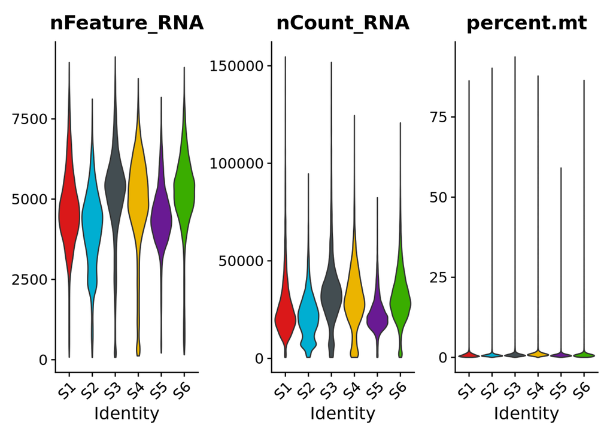

```r
aggr[["percent.mt"]] = PercentageFeatureSet(aggr, pattern="^MT-")
VlnPlot(aggr, features = c("nFeature_RNA", "nCount_RNA", "percent.mt"), ncol = 3, pt.size = 0, cols=pal)
```

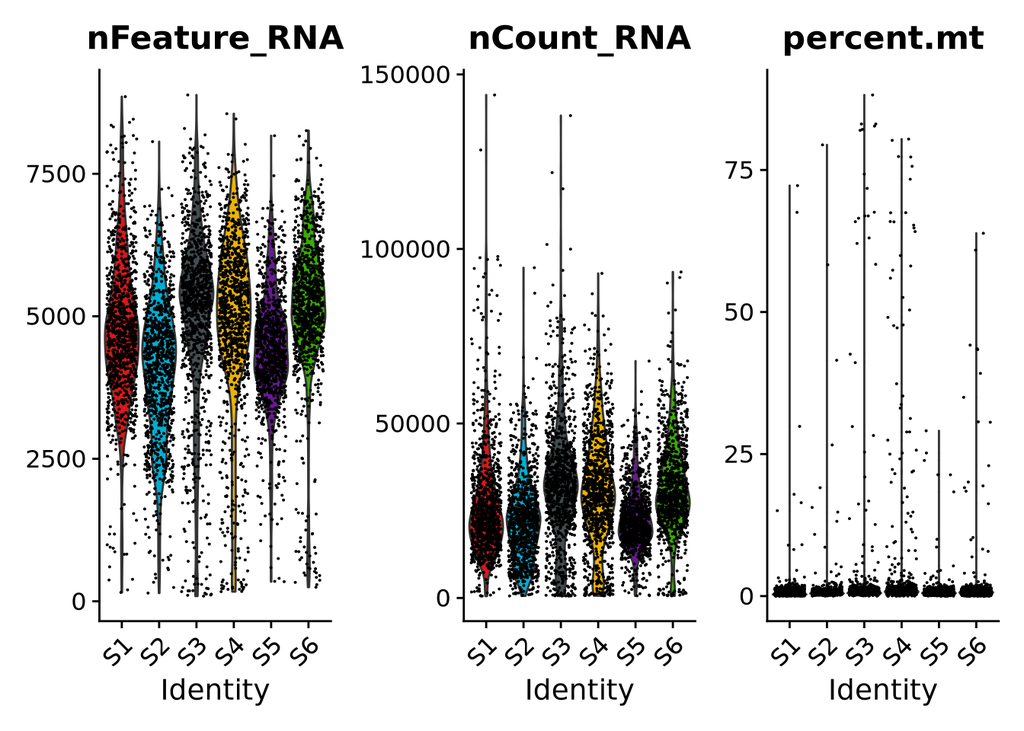

```r
VlnPlot(subset(x = aggr, downsample = 1000), features = c("nFeature_RNA", "nCount_RNA", "percent.mt"), ncol = 3, cols=pal)
```

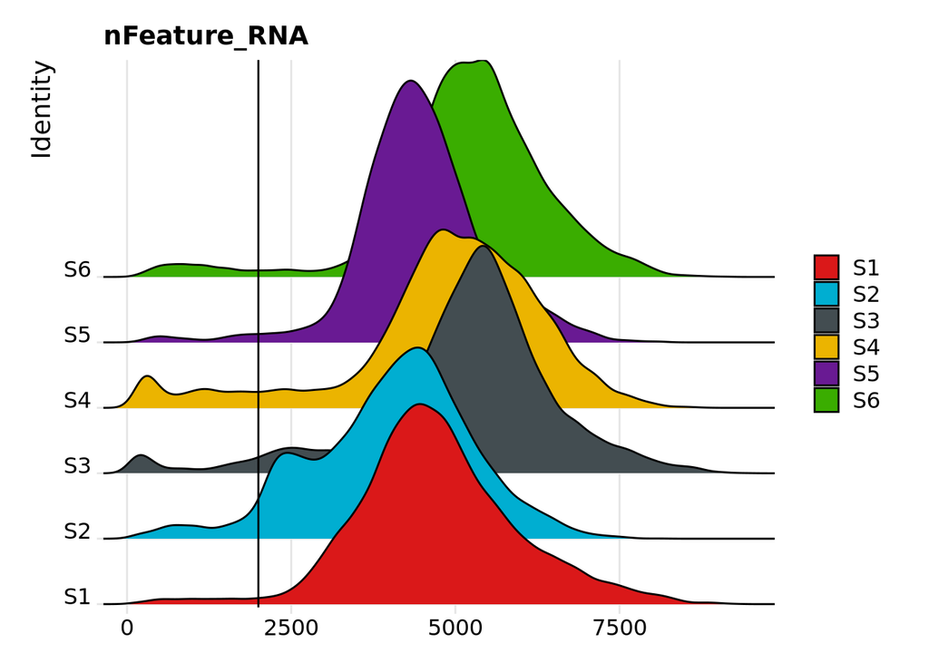

```r
RidgePlot(aggr, feature= "nFeature_RNA", cols=pal) + geom_vline(aes(xintercept=2000))
```

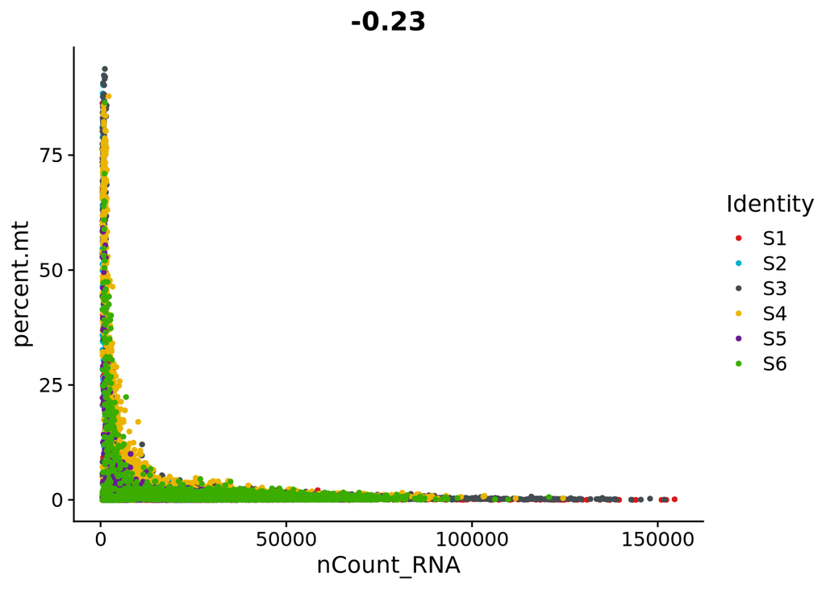

```r
FeatureScatter(aggr, feature1 = "nCount_RNA", feature2 = "percent.mt", cols=pal)
```

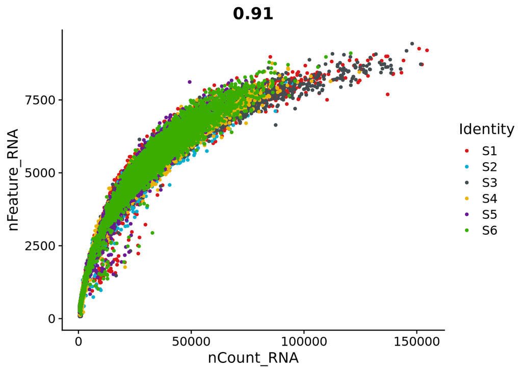

```r
FeatureScatter(aggr, feature1 = "nCount_RNA", feature2 = "nFeature_RNA", cols=pal)
```

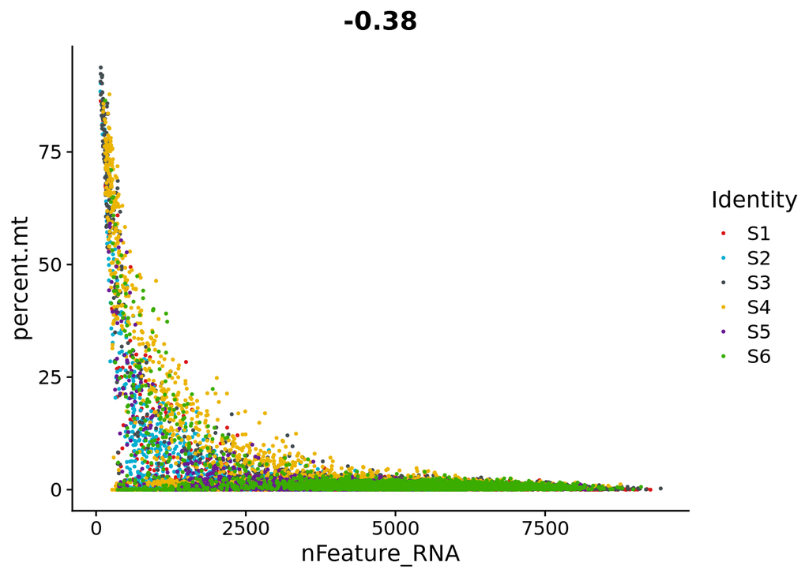

```r
FeatureScatter(aggr, feature1 = "nFeature_RNA", feature2 = "percent.mt", pt.size = 0.5, cols=pal)
```

We set an adaptive Mt.percent filter that’s the 3* mad maximum.

```r
mt_info = group_by(aggr@meta.data, subject) %>%
  summarise(mad = mad(percent.mt),
            median = median(percent.mt),
            thresh = median(percent.mt) + mad(percent.mt)*3,
            th95 = quantile(percent.mt, 0.95))
mt_info
```

```
## # A tibble: 6 × 5
##   subject   mad median thresh  th95
##   <chr>   <dbl>  <dbl>  <dbl> <dbl>
## 1 S1      0.437  0.562   1.87  1.69
## 2 S2      0.327  0.599   1.58  1.74
## 3 S3      0.389  0.705   1.87  2.29
## 4 S4      0.503  0.933   2.44 10.3
## 5 S5      0.356  0.617   1.68  1.47
## 6 S6      0.450  0.645   2.00  1.77
```

```r
thresh = max(mt_info$thresh)
```

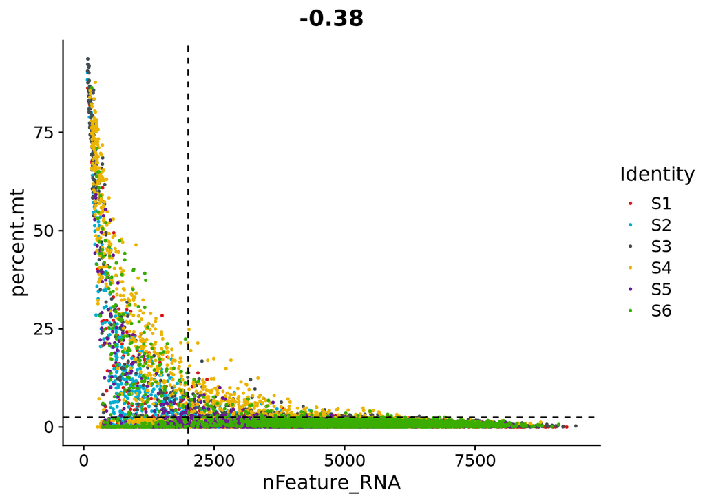

```r
FeatureScatter(aggr, feature1 = "nFeature_RNA", feature2 = "percent.mt", pt.size = 0.5, cols=pal) +
  geom_hline(aes(yintercept=thresh), linetype="dashed") +
  geom_vline(aes(xintercept=2000), linetype="dashed")
```

```r
ncol(aggr)
```

```
## [1] 59720
```

```r
filt <- subset(aggr,  percent.mt < thresh & nFeature_RNA > 2000)
ncol(filt)
```

```
## [1] 56638
```

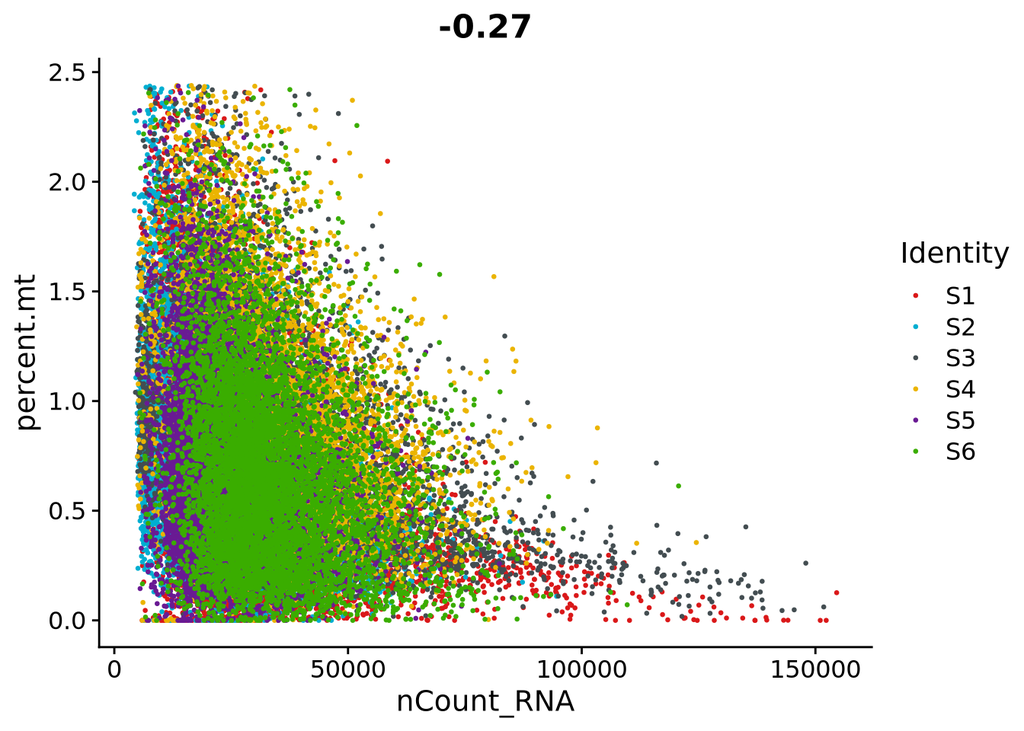

```r
FeatureScatter(filt, feature1 = "nCount_RNA", feature2 = "percent.mt", pt.size=0.5, cols=pal)
```

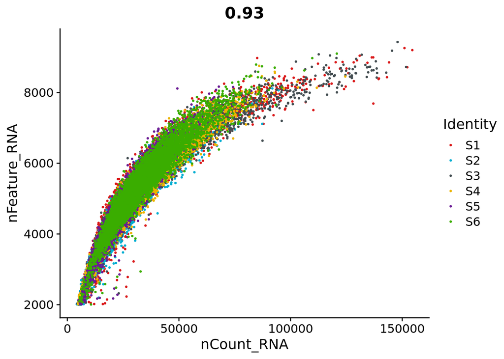

```r
FeatureScatter(filt, feature1 = "nCount_RNA", feature2 = "nFeature_RNA", pt.size=0.5, cols=pal)
```

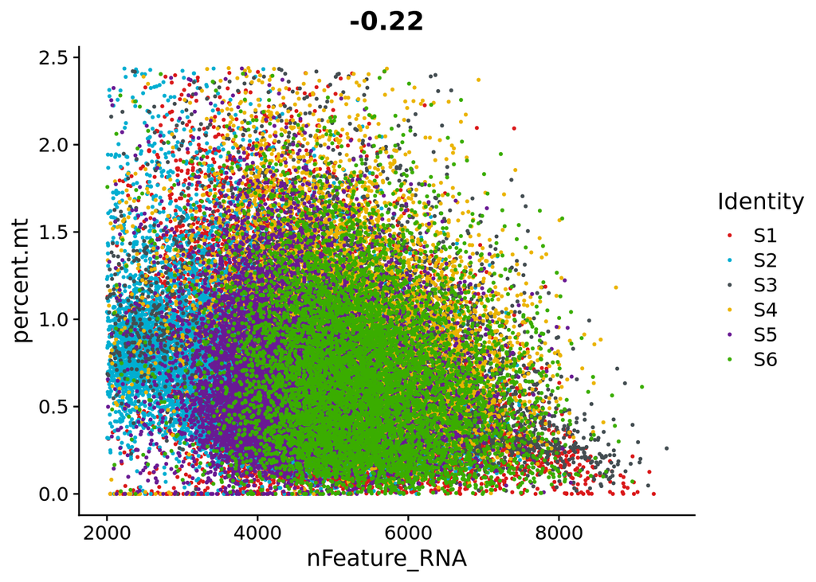

```r
FeatureScatter(filt, feature1 = "nFeature_RNA", feature2 = "percent.mt", pt.size = 0.5, cols=pal)
```

## Normalise

```r
filt= NormalizeData(filt, normalization.method = "LogNormalize", scale.factor = 10000)
```

```
## Normalizing layer: counts
```

## Identification of Variable Features

```r
filt <- FindVariableFeatures(filt, selection.method = "vst", nfeatures = 2000)
```

```
## Finding variable features for layer counts
```

```r
# Identify the 10 most highly variable genes
prev_var_feat = VariableFeatures(filt)
top10 <- head(VariableFeatures(filt), 10)

# plot variable features with and without labels
plot1 = VariableFeaturePlot(subset(filt, downsample=1000))
plot2 <- LabelPoints(plot = plot1, points = top10, repel = TRUE)
```

```
## When using repel, set xnudge and ynudge to 0 for optimal results
```

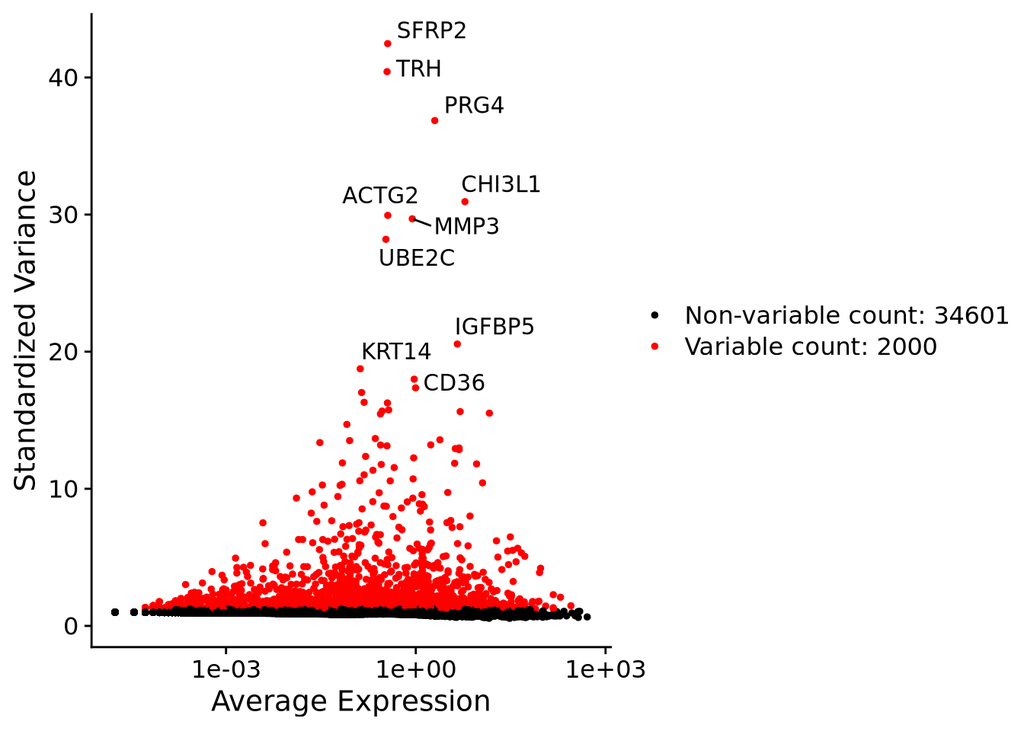

```r
plot2
```

## Scaling

Centres around zero and sets the variance to 1 - basically a z-score transformation. Here we use all genes, but by default Seurat uses only identified variable features.

```r
all.genes = rownames(filt)
filt = ScaleData(filt, features=all.genes, vars.to.regress=c("nCount_RNA", "percent.mt"))
filt = FindVariableFeatures(filt)
```

```
## Finding variable features for layer counts
```

```r
new_var_feat = VariableFeatures(filt)
summary(new_var_feat == prev_var_feat)
```

```
##    Mode    TRUE
## logical    2000
```

## PCA

PC1 is separating a small number of cells from the main group. MKI67 is very much a prolif/cell cycle gene.

```r
filt = RunPCA(filt)
```

```
## PC_ 1
## Positive:  MKI67, ANLN, TPX2, TUBA1B, CENPF, RRM2, BIRC5, CDC20, PRC1, SHCBP1
##     NUSAP1, CEP55, TK1, CCNA2, TUBB4B, UBE2C, CCNB1, DIAPH3, MAD2L1, ASPM
##     PLK1, CENPM, DLGAP5, CDCA3, KNL1, PFN1, CFL1, HMMR, KIF23, STMN1
## Negative:  COL3A1, FBLN2, SERPING1, DCN, SOD2, CYP1B1, CCN5, MFAP4, FGF7, CFB
##     TNFAIP6, ZFAS1, NEAT1, SAT1, MGP, CDKN1A, LUM, JUNB, CRLF1, EPSTI1
##     TSHZ2, AKR1C3, GPNMB, SOX4, CFD, AKR1C1, FBLN1, IFITM1, ZFP36L1, COL6A3
## PC_ 2
## Positive:  TAGLN, TPM1, TPM2, NREP, ACTN1, SPARC, ACTA2, THBS1, SEPTIN11, PLOD2
##     CCN2, GLS, PDLIM7, BNIP3, CCN1, TNC, EIF4EBP1, CDH2, CNN2, BGN
##     MYL9, PGK1, TPI1, ACTB, CSRP1, LOXL2, FGF2, COL12A1, MYL12A, LOX
## Negative:  CTSL, AKR1C1, HMGA1, IGFBP6, AKR1C3, CLEC3B, AKR1C2, SNED1, SCARA3, PCOLCE2
##     IGFBP4, BMERB1, NT5E, LSP1, LXN, PTGES, ADIRF, LRRN4CL, TNXB, PDGFRA
##     FBLN1, CXCL12, CBR3, GSN, OAF, AKAP12, ZFP36L2, ISLR, FBLN2, BDKRB2
## PC_ 3
## Positive:  S100A10, SH3BGRL3, POLR2L, S100A6, ANXA5, CLEC3B, AKAP12, TXN, PCOLCE2, TNXB
##     ADIRF, MYL6, PRSS23, AHNAK, LMO7, ANXA2, MFAP5, CLIC3, ITGBL1, LMNA
##     LIMS2, IGFBP6, RALGPS2, SPTBN1, VSIR, DKK1, CRYAB, ADAMTS1, ACTB, GSN
## Negative:  BGN, MFAP4, COL6A3, ZFAS1, COL3A1, MKI67, PLK1, CENPF, SOX4, CDC20
##     UBE2C, TGFBI, NUSAP1, TOP2A, HMMR, ANLN, CCNA2, DEPDC1, CDCA8, ZFP36L1
##     CEP55, CCNB1, ITGA11, CKAP2L, CENPE, KIF2C, NUF2, CENPA, TACC3, CHI3L1
## PC_ 4
## Positive:  EFEMP1, MFAP5, FBN1, PI16, ELN, CCDC80, PRSS23, ZFAS1, LINC01133, FBLN2
##     DEPTOR, CYP1B1, PTGIS, SEMA3C, SCRG1, COMP, HEG1, H19, SLIT3, PSAT1
##     CRLF1, TGFBI, LIMS2, TNXB, PTX3, ITGA11, ASS1, COL5A1, DDIT4, NEK7
## Negative:  MT2A, SPOCD1, CTHRC1, HMGA1, PHLDA1, BAALC, DCBLD2, MT1E, CCND1, SPON2
##     CALR, CD82, SPHK1, PTGER2, GAP43, FRMD4A, SLC20A1, ARHGAP22, ENPP1, FGF5
##     PLAUR, DRAP1, FABP5, SH3BGRL3, GNG11, TBX3, TPM2, NR2F2, RPL22L1, TUBA1B
## PC_ 5
## Positive:  FGF7, REV3L, ADM, COLEC12, CNN2, SOD3, PLPP3, ANGPT1, CYB5A, SYNPO2
##     FBLN5, SOD2, RHOBTB3, SLIT3, GPX3, LMOD1, CRISPLD2, MRVI1, THBS1, NID2
##     PSG5, GREM1, COL12A1, TNS3, ENPP2, EMX2OS, SFRP1, MDK, SPON2, IGFBP4
## Negative:  S100A16, SERPINE2, NTM, ANKH, ENG, IGFBP3, HLA-B, SPARC, TIMP3, TRIB3
##     SCRG1, SH3BGRL3, ZFAS1, VCAN, MICAL2, LINC01133, PSAT1, PRSS3, TNFRSF12A, LTBP1
##     EIF4EBP1, SLC38A5, PI16, PLAUR, LOXL4, MYDGF, EIF5A, UNC5B, GATD3A, NME1
```

```r
print(filt[["pca"]], dims = 1:5, nfeatures = 5)
```

```
## PC_ 1
## Positive:  MKI67, ANLN, TPX2, TUBA1B, CENPF
## Negative:  COL3A1, FBLN2, SERPING1, DCN, SOD2
## PC_ 2
## Positive:  TAGLN, TPM1, TPM2, NREP, ACTN1
## Negative:  CTSL, AKR1C1, HMGA1, IGFBP6, AKR1C3
## PC_ 3
## Positive:  S100A10, SH3BGRL3, POLR2L, S100A6, ANXA5
## Negative:  BGN, MFAP4, COL6A3, ZFAS1, COL3A1
## PC_ 4
## Positive:  EFEMP1, MFAP5, FBN1, PI16, ELN
## Negative:  MT2A, SPOCD1, CTHRC1, HMGA1, PHLDA1
## PC_ 5
## Positive:  FGF7, REV3L, ADM, COLEC12, CNN2
## Negative:  S100A16, SERPINE2, NTM, ANKH, ENG
```

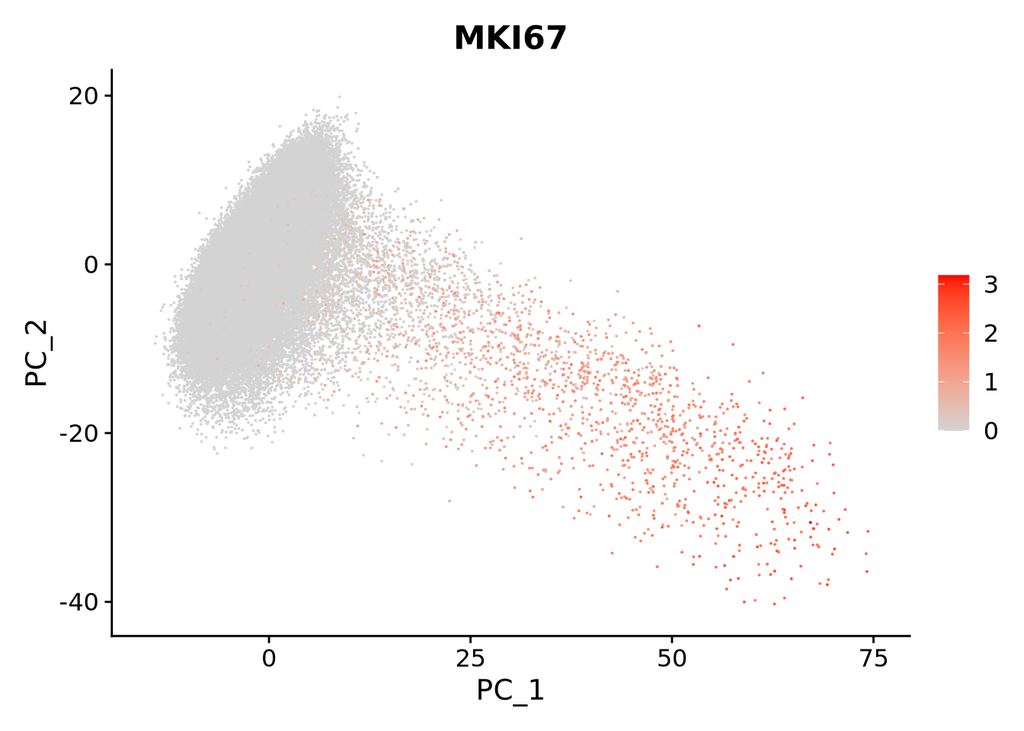

```r
FeaturePlot(filt, reduction = "pca", feature="MKI67", cols=c("lightgrey","red"))
```

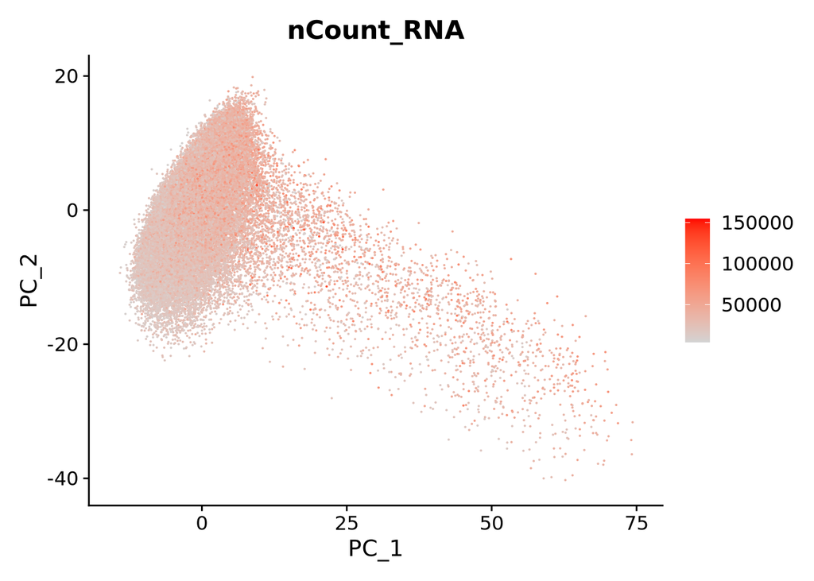

```r
FeaturePlot(filt, reduction = "pca", feature="nCount_RNA", cols=c("lightgrey","red"))
```

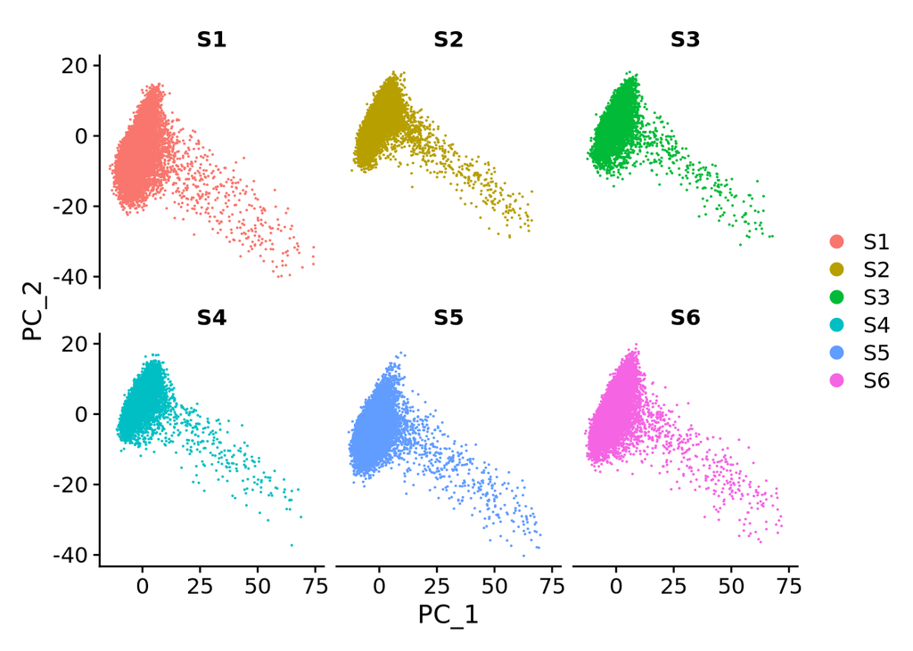

```r
DimPlot(filt, reduction="pca", shuffle=T, split.by = "orig.ident", ncol=3)
```

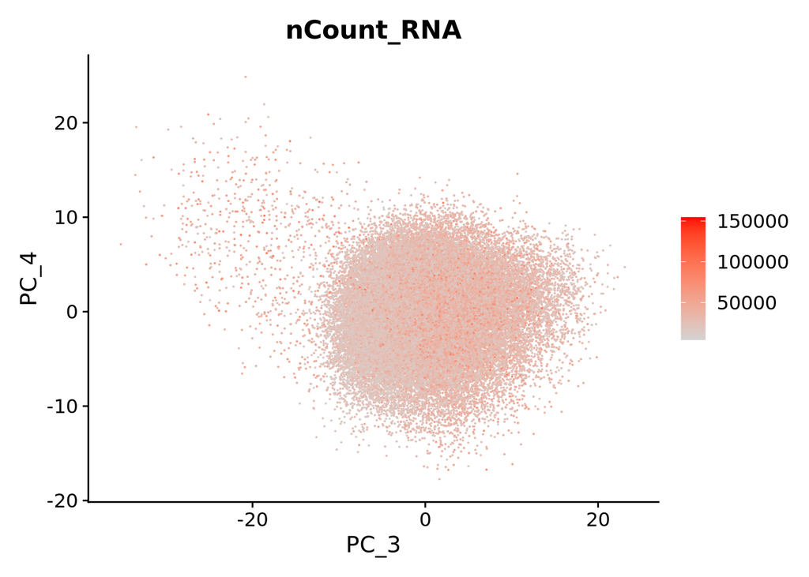

```r
FeaturePlot(filt, reduction = "pca", feature="nCount_RNA", cols=c("lightgrey","red"), dims = c(3,4))
```

## Determine the dimensionality

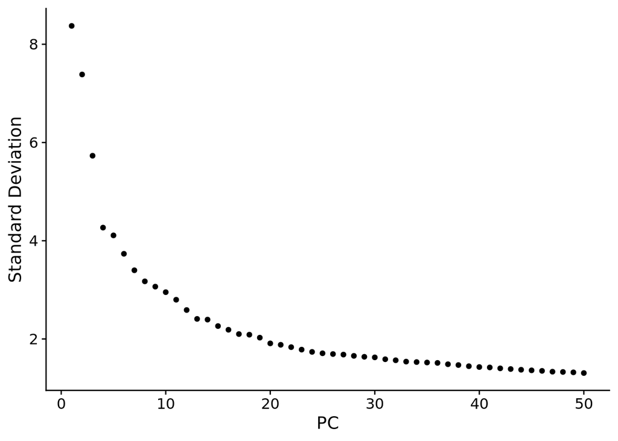

```r
ElbowPlot(filt, ndims = 50)
```

## Clustering

```r
filt <- FindNeighbors(filt, dims = 1:20)
filt <- FindClusters(filt, resolution = 0.5)
```

```
## Modularity Optimizer version 1.3.0 by Ludo Waltman and Nees Jan van Eck
##
## Number of nodes: 56638
## Number of edges: 1588661
##
## Running Louvain algorithm...
## Maximum modularity in 10 random starts: 0.8828
## Number of communities: 9
## Elapsed time: 20 seconds
```

```r
table(Idents(filt))
```

```
##
##    0    1    2    3    4    5    6    7    8
## 9348 9292 8223 7809 7427 7069 3921 2676  873
```

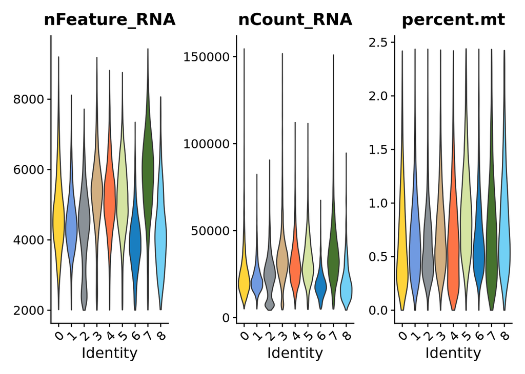

```r
VlnPlot(filt, features = c("nFeature_RNA", "nCount_RNA", "percent.mt"), ncol = 3, pt.size = 0, cols=clusters)
```

### Cluster Composition

```r
composition = group_by(filt@meta.data, subject,seurat_clusters) %>% count()
composition = composition[order(composition$n, decreasing = T),]
colnames(composition) = c("donor_id","seurat_clusters","n_cells")
head(composition)
```

```
## # A tibble: 6 × 3
## # Groups:   donor_id, seurat_clusters [6]
##   donor_id seurat_clusters n_cells
##   <chr>    <fct>             <int>
## 1 S5       1                  8737
## 2 S1       0                  8167
## 3 S2       2                  8100
## 4 S3       3                  7424
## 5 S4       5                  6687
## 6 S6       4                  5424
```

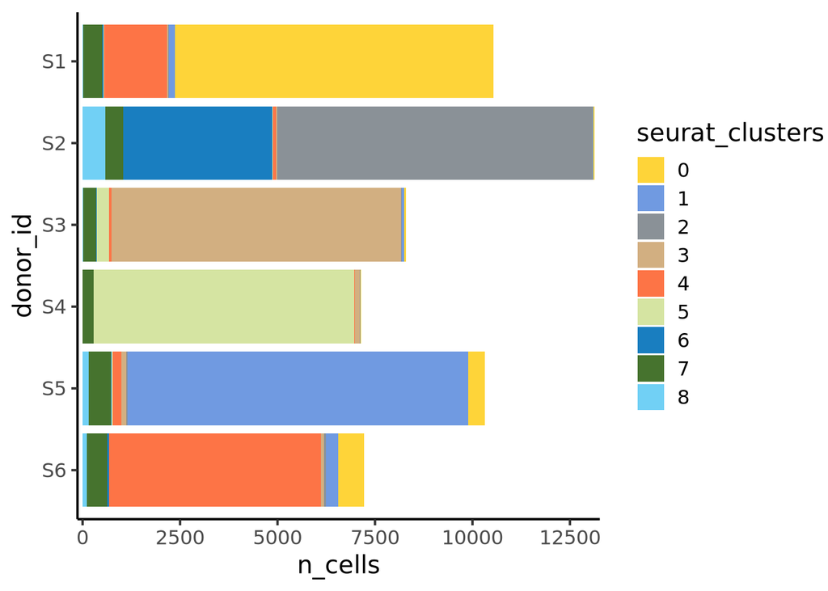

```r
ggplot(composition) + geom_bar(stat="identity",aes(y=donor_id, x=n_cells, fill=seurat_clusters)) +
  scale_y_discrete(limits=rev)+ scale_x_continuous(expand = c(0.01, 0))+
  theme_classic(base_size=15) + scale_fill_manual(values=clusters)
```

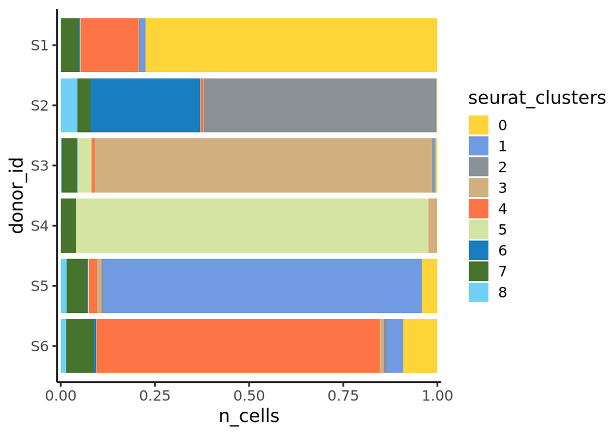

```r
ggplot(composition) + geom_bar(stat="identity",aes(y=donor_id, x=n_cells, fill=seurat_clusters), position = "fill") +
  scale_y_discrete(limits=rev)+ scale_x_continuous(expand = c(0.01, 0))+
  theme_classic(base_size=15)  + scale_fill_manual(values=clusters)
```

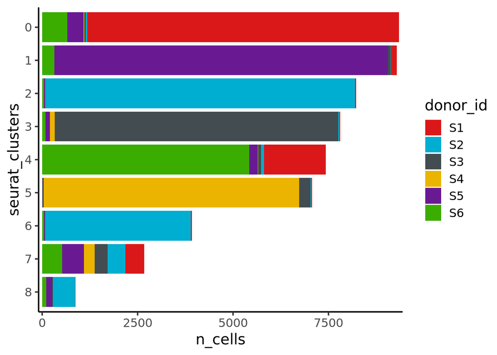

```r
ggplot(composition) + geom_bar(stat="identity",aes(fill=donor_id, x=n_cells, y=seurat_clusters)) +
    scale_y_discrete(limits=rev)+ scale_fill_manual(values=pal)  + scale_x_continuous(expand = c(0.01, 0))+
  theme_classic(base_size=15)
```

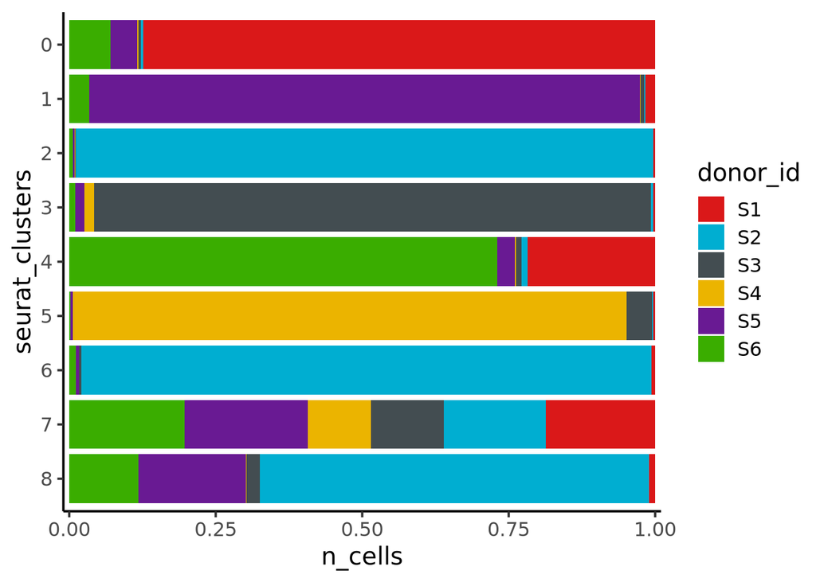

```r
ggplot(composition) + geom_bar(stat="identity",aes(fill=donor_id, x=n_cells, y=seurat_clusters), position = "fill") +
  scale_y_discrete(limits=rev)+ scale_fill_manual(values=pal)  + scale_x_continuous(expand = c(0.01, 0))+
  theme_classic(base_size=15)
```

## Non-linear dimensionality reduction

```r
filt = RunUMAP(filt, dims=1:20)
```

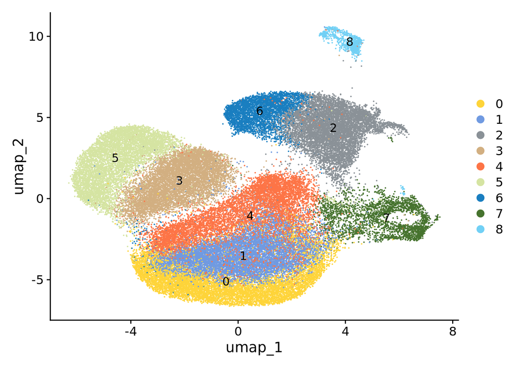

```r
DimPlot(filt, reduction="umap", label=T, cols=clusters)
```

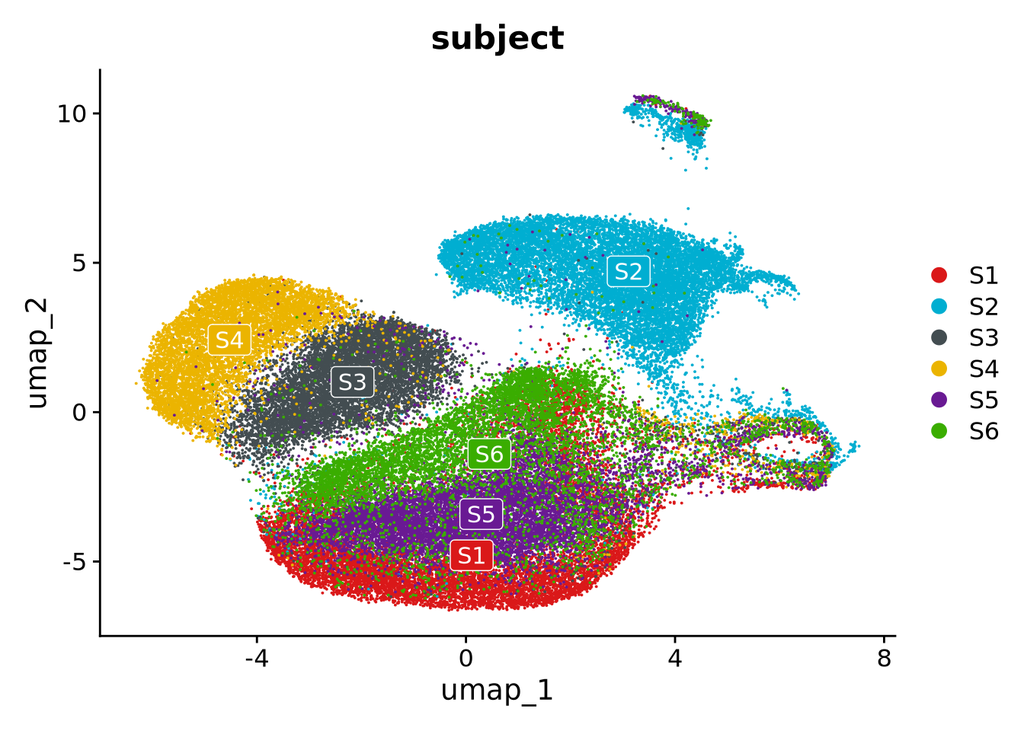

```r
DimPlot(filt, reduction="umap", group.by = "subject", label=T, cols=pal, label.color = "white", label.box=T)
```

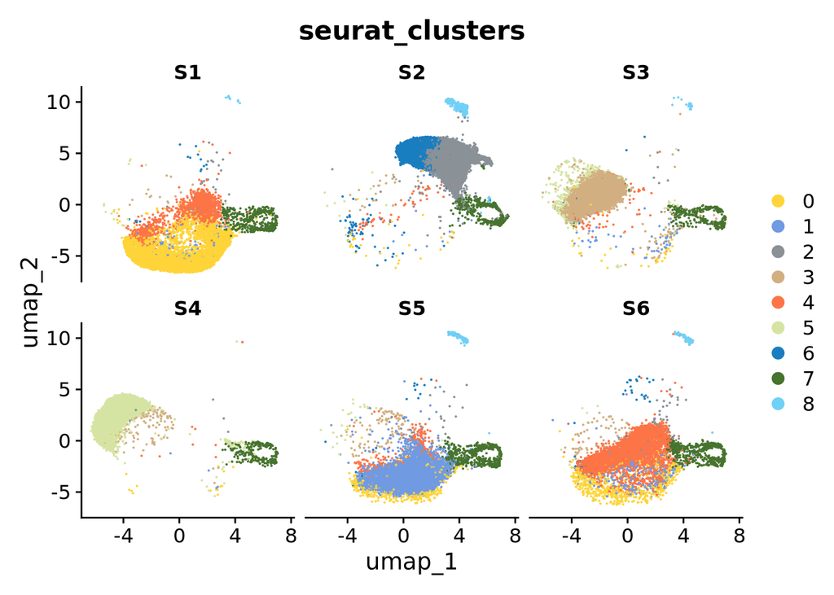

```r
DimPlot(filt, reduction="umap", split.by = "subject",group.by = "seurat_clusters", ncol=3, cols = clusters)
```

## Integrate

```r
method_name="rpca"
red_name = paste("integrated", sep=".", method_name)
umap_name = paste("umap", sep=".", method_name)
clu_name = paste( method_name, sep="_", "clusters")
```

```r
filt[["RNA"]] <- split(filt[["RNA"]], f = filt$orig.ident)
```

```
## Splitting 'counts', 'data' layers. Not splitting 'scale.data'. If you would like to split other layers, set in `layers` argument.
```

```r
filt = IntegrateLayers(filt, method= RPCAIntegration, orig.reduction = "pca",
                       new.reduction = red_name)
```

```
## Computing within dataset neighborhoods
```

```
## Finding all pairwise anchors
```

```
## Projecting new data onto SVD
## Projecting new data onto SVD
```

```
## Finding neighborhoods
```

```
## Finding anchors
```

```
##  Found 6074 anchors
```

```
## Projecting new data onto SVD
## Projecting new data onto SVD
```

```
## Finding neighborhoods
```

```
## Finding anchors
```

```
##  Found 7222 anchors
```

```
## Projecting new data onto SVD
## Projecting new data onto SVD
```

```
## Finding neighborhoods
```

```
## Finding anchors
```

```
##  Found 7903 anchors
```

```
## Projecting new data onto SVD
## Projecting new data onto SVD
```

```
## Finding neighborhoods
```

```
## Finding anchors
```

```
##  Found 7169 anchors
```

```
## Projecting new data onto SVD
## Projecting new data onto SVD
```

```
## Finding neighborhoods
```

```
## Finding anchors
```

```
##  Found 6859 anchors
```

```
## Projecting new data onto SVD
## Projecting new data onto SVD
```

```
## Finding neighborhoods
```

```
## Finding anchors
```

```
##  Found 10513 anchors
```

```
## Projecting new data onto SVD
## Projecting new data onto SVD
```

```
## Finding neighborhoods
```

```
## Finding anchors
```

```
##  Found 9987 anchors
```

```
## Projecting new data onto SVD
## Projecting new data onto SVD
```

```
## Finding neighborhoods
```

```
## Finding anchors
```

```
##  Found 6826 anchors
```

```
## Projecting new data onto SVD
## Projecting new data onto SVD
```

```
## Finding neighborhoods
```

```
## Finding anchors
```

```
##  Found 8283 anchors
```

```
## Projecting new data onto SVD
## Projecting new data onto SVD
```

```
## Finding neighborhoods
```

```
## Finding anchors
```

```
##  Found 6423 anchors
```

```
## Projecting new data onto SVD
## Projecting new data onto SVD
```

```
## Finding neighborhoods
```

```
## Finding anchors
```

```
##  Found 9034 anchors
```

```
## Projecting new data onto SVD
## Projecting new data onto SVD
```

```
## Finding neighborhoods
```

```
## Finding anchors
```

```
##  Found 6742 anchors
```

```
## Projecting new data onto SVD
## Projecting new data onto SVD
```

```
## Finding neighborhoods
```

```
## Finding anchors
```

```
##  Found 7570 anchors
```

```
## Projecting new data onto SVD
## Projecting new data onto SVD
```

```
## Finding neighborhoods
```

```
## Finding anchors
```

```
##  Found 6970 anchors
```

```
## Projecting new data onto SVD
## Projecting new data onto SVD
```

```
## Finding neighborhoods
```

```
## Finding anchors
```

```
##  Found 8613 anchors
```

```
## Merging dataset 4 into 3
```

```
## Extracting anchors for merged samples
```

```
## Finding integration vectors
```

```
## Finding integration vector weights
```

```
## Integrating data
```

```
## Merging dataset 6 into 1
```

```
## Extracting anchors for merged samples
```

```
## Finding integration vectors
```

```
## Finding integration vector weights
```

```
## Integrating data
```

```
## Merging dataset 5 into 1 6
```

```
## Extracting anchors for merged samples
```

```
## Finding integration vectors
```

```
## Finding integration vector weights
```

```
## Integrating data
```

```
## Merging dataset 2 into 3 4
```

```
## Extracting anchors for merged samples
```

```
## Finding integration vectors
```

```
## Finding integration vector weights
```

```
## Integrating data
```

```
## Merging dataset 1 6 5 into 3 4 2
```

```
## Extracting anchors for merged samples
```

```
## Finding integration vectors
```

```
## Finding integration vector weights
```

```
## Integrating data
```

```r
filt <- FindNeighbors(filt, reduction =  red_name, dims = 1:20, verbose=F)
filt <- FindClusters(filt, resolution = 0.5, cluster.name =  clu_name)
```

```
## Modularity Optimizer version 1.3.0 by Ludo Waltman and Nees Jan van Eck
##
## Number of nodes: 56638
## Number of edges: 1487914
##
## Running Louvain algorithm...
## Maximum modularity in 10 random starts: 0.8263
## Number of communities: 12
## Elapsed time: 20 seconds
```

```r
filt <- RunUMAP(filt, reduction = red_name, dims = 1:20, reduction.name = umap_name)
```

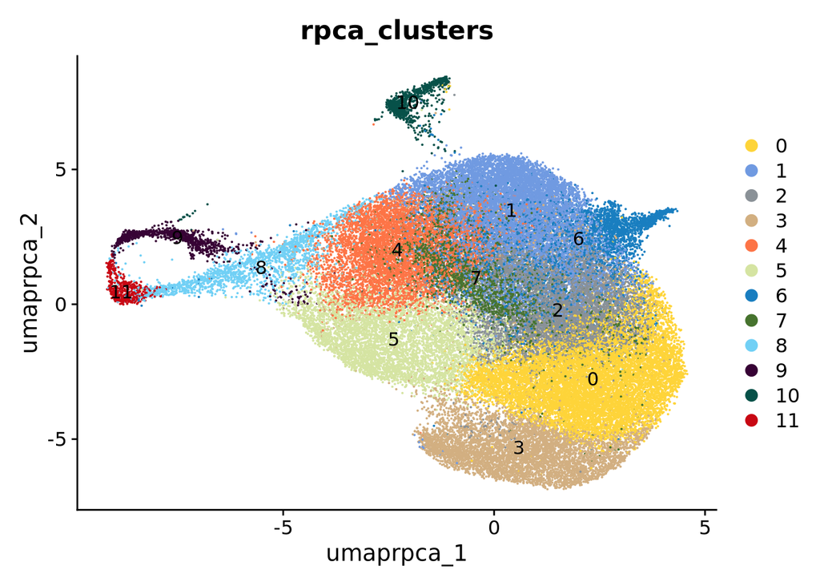

```r
DimPlot(filt, reduction = umap_name,  group.by = clu_name, label=T,cols=clusters)
```

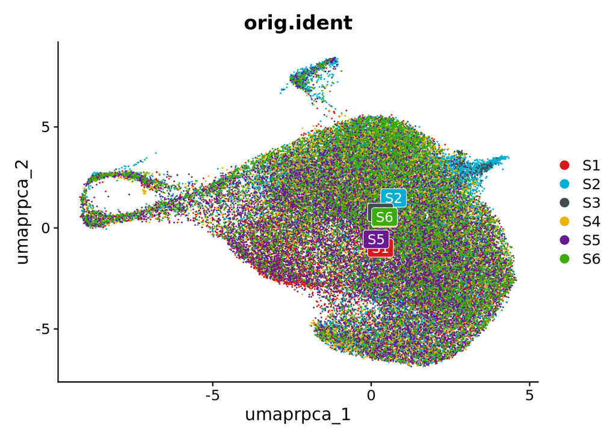

```r
DimPlot(filt, reduction = umap_name,  group.by = "orig.ident", label=T, cols=pal, label.color = "white", label.box = T )
```

### Save

```r
if (subset_data == FALSE){
  saveRDS(filt, file = here(odir, "complete_analysis.rds"))
  write.table(composition, here(odir, "cluster_composition.txt"),
              sep="\t", row.names = F)
  Idents(filt) = "orig.ident"
  sub = subset(filt, downsample=1000)
  Idents(filt) = "seurat_clusters"
  saveRDS(sub,here(odir,"10%_complete_analysis.rds"))
} else if (subset_data){ #if subset, don't save complete analysis
  saveRDS(filt,here(odir, "10%_subset_analysis.rds"))
  write.table(cluster.markers, file.path(odir,dataname, "10%_subset_marker_genes.txt"),
            sep="\t", row.names = F)
}
```